# MODELO DE PREDICCIÓN DEL NÚMERO DE HIJOS EN LOS HOGARES COLOMBIANOS

Carlos Mario Calle González

Catherine Andrea Córdoba Espinosa

Allison Piedrahita García

Santiago Ramírez Zapata

Jhonier Santiago Serna Cardona

01/06/2021

## Introducción

Gran parte de las políticas públicas de un país se formulan teniendo en cuenta el número de habitantes de su territorio [1], por ello, conocer el comportamiento de la natalidad se convierte en un factor clave para las instituciones gubernamentales. Teniendo en cuenta lo anterior, se decide desarrollar un modelo de predicción el cual determine la cantidad de hijos que tendría un hogar de acuerdo a las dinámicas y características propias de dicha unidad de estudio.A continuación, se expondrá de manera detallada y secuencial, los pasos seguidos para el desarrollo del modelo objetivo.

## Alcance

El planteamiento del modelo de predicción se desarrollará para los hogares colombianos, debido a que se cuenta con la información suficiente para realizar un modelo sólido que proporcione resultados similares a los reales.

## Público objetivo

La utilidad del modelo de predicción se encuentra mayormente en el desarrollo de políticas públicas del país, con el fin de establecer medidas de bienestar en cada uno de los hogares, refiriéndose al goce de los derechos de la familia y de cada uno de sus integrantes [1]. Por lo anterior, la creación del modelo de predicción y su posterior aplicación se encuentra dirigida específicamente a entidades gubernamentales, para que dichas instituciones puedan sacar provecho de los resultados obtenidos.

## Estado del arte en Colombia

Según estudios realizados por el Departamento Administrativo Nacional de Estadística (DANE), con el fin de comprender la estructura y la dinámica de las familias e identificar los problemas a los que se enfrentan; en los cuales se hace un análisis de la composición y cambios en la familia Colombiana identificando los factores asociados a los principales cambios [2]. Se plantea que la estructura familiar depende de muchas variables sociales, tales como la edad, sexo, el estado conyugal, el nivel educativo de los jefes, entre otros. Dichos factores se pueden englobar en 4 aspectos demográficos, que son:

- **Culturales:** Según la región, creencias religiosas, importancia de las relaciones en pareja, entre otras
- **Socioeconómicos:** Zonas urbanas, costo de la vivienda, ingresos y aumento de la oferta laboral.
- **Demográficos:** Características de la población, mortalidad infantil, separación de parejas.
- **Políticos:** Referente a deberes del estado frente a la población, educación, permisos maternales, disponibilidad de guarderías. [3]

## Fuentes de información y segmentación de variables

Para el presente trabajo se tomó la base de datos correspondiente a la encuesta nacional de calidad de vida 2018-2019, proporcionada por el Departamento Administrativo Nacional de Estadística (DANE) por medio del archivo nacional de datos (ANDA) . De allí, se usaron 9 tablas, que corresponden a: Datos de la vivienda , servicios del hogar, características y composición del hogar, salud, educación, fuerza de trabajo, condiciones de vida del hogar y tenencia de bienes, y uso energético del hogar.

De las más de 150 variables contenidas en el total de datos, se hizo una primera elección teniendo encuenta las siguientes consideraciones:

- Se tomaron las variables que podrían afectar de manera significativa la predicción del modelo sobre el número de hijos por hogar, teniendo en cuenta los factores asociados a la natalidad consultados en la literatura y mencionados anteriormente.
- Se tomaron las variables que estuvieran bien categorizadas y que no tuveran registro de frases y/o letras.
- Se tomaron variables que no tuvieran una gran cantidad de datos vacios para evitar una reducción drástica de la base de datos.
- Se tomaron aquellos hogares en donde viviera una única familia.

### Base de datos

Con las consideraciones mencionadas se obtiene una primera base de datos filtrada. Sin embargo, se observan dos inconvenientes principales que debían ser solucionados para evitar futuros obstáculos con el modelo:

- Para variables aparentemente importantes según la literatura, como por ejemplo si el jefe del hogar vive o no con su cónyuge, habían respuestas vacías.
  - La solución que se plateó fue llevar dichas respuestas vacías a una respuesta negativa. En caso de que esta no existiera, se creaba una nueva respuesta dónde se consideraba desconocimiento por parte de la persona, es decir, no sabe/no responde.
- Para el mismo hogar, se tenían dos filas de datos que debían apuntar a la misma predicción, pues se trataban de respuestas dadas por el jefe del hogar y el cónyuge del jefe del hogar.
  - La solución que se planteó fue crear nuevas variables especificando si se trataba del jefe del hogar o del cónyuge, esto para el mismo hogar. Esto ocasionó que se duplicaran la cantidad de variables, pero mantuvo la información relevante para cada familia.

Con lo anterior, se llegó a una tabla final con $74$ variables las cuales fueron analizadas estadísticamente para llevar a cabo una segunda selección.

*TENIENDO EN CUENTA LO ANTERIOR, SE CONCLUYÓ QUE EL MODELO ESTARÍA LIMITADO PARA HOGARES DONDE HUBIERA PRESENCIA DE UNA SOLA FAMILIA Y ADICIONALMENTE QUE HUBIERA PRESENCIA DE LOS DOS CÓNYUGES EN EL HOGAR*

## Descripción de variables

- *DIRECTORIO:* número utilizado para identificar cada uno de los hogares.
- *ID_Jefe / ID_Cónyuge:* hace referencia al tipo de documento de identidad que posee el jefe del hogar y el cónyuge del jefe del hogar. La variable se encuentra categorizada de la siguiente manera:

  ```
  1. Registro civil de nacimiento

  2. Tarjeta de identidad

  3. Cédula de ciudadanía

  4. Cédula de extranjería

  5. No posee ID
  ```

- *SEXO_Jefe / SEXO_Cónyuge:* se refiere a la categorización biológica del jefe del hogar y del cónyuge del jefe del hogar. Así:

  ```
  1. Hombre

  2. Mujer
  ```

- *EDAD_Jefe / EDAD_Cónyuge:* cantidad de años del jefe del hogar y del cónyuge del jefe del hogar.
- *PARENTESCO:* hace referencia al nivel de mando en el hogar, se encuentra categorizada así:

  ```
  1. Jefe de hogar

  2. Pareja del jefe de hogar
  ```

- *ESTADO_CIVIL:*se refiere a la situación familiar provenientes de las relaciones de pareja. Entre las categorías se encuentran:

  ```
  1. No casado(a) y vive con la pareja hace menos de 2 años

  2. No casado(a) y vive con la pareja hace más de 2 años

  6. Casado(a)
  ```

- *PADRE_VIVE_Jefe / PADRE_VIVE_Cónyuge:* expone si el padre del jefe o del cónyuge del jefe vive en el hogar, a través de las siguientes categorías:

  ```
  1. Sí

  2. No

  3. Fallecido
  ```

- *MADRE_VIVE_Jefe / MADRE_VIVE_Cónyuge:* expone si la madre del jefe o del cónyuge del jefe vive en el hogar, a través de las siguientes categorías:

  ```
  1. Sí

  2. No

  3. Fallecida
  ```

- *CULTURA_Jefe / CULTURA_Cónyuge:* hace referencia al reconocimiento del jefe del hogar o del cónyuge del jefe del hogar, segun su pueblo o rasgos físicos, a alguna de las siguientes categorías/comunidades:

  ```
  1. Indígena

  2. Gitano(a) (Rom)

  3. Raizal del archipiélago de San Andrés, Providencia y Santa Catalina.

  4. Palenquero(a) de San Basilio.

  5. Negro(a), mulato(a) (afrodescendiente), afrocolombiano(a).

  6. Ninguno de los anteriores.
  ```

- *CAMPESINO_Jefe / CAMPESINO_Cónyuge:* hace referencia a si el jefe del hogar o cónyuge del jefe del hogar se consideran campesinos:

  ```
  1. Sí

  2. No
  ```

- *SATISFACCIÓN_VIDA_Jefe / SATISFACCIÓN_VIDA_Cónyuge:* se refiere al nivel de satisfacción del jefe del hogar o del cónyuge del jefe del hogar con su vida actual, en una escala del 0 al 10, donde 0 significa que se siente “totalmente insatisfecho” y 10 significa que se siente “totalmente satisfecho”.
- *SATISFACCIÓN_ECONÓMICA_Jefe / SATISFACCIÓN_ECONÓMICA_Cónyuge:* se refiere al nivel de satisfacción del jefe del hogar o del cónyuge del jefe del hogar con su economía actual, en una escala del 0 al 10, donde 0 significa que se siente “totalmente insatisfecho” y 10 significa que se siente “totalmente satisfecho”.
- *SATISFACCIÓN_SALUD_Jefe / SATISFACCIÓN_SALUD_Cónyuge:* se refiere al nivel de satisfacción del jefe del hogar o del cónyuge del jefe del hogar con su salud actual, en una escala del 0 al 10, donde 0 significa que se siente “totalmente insatisfecho” y 10 significa que se siente “totalmente satisfecho”.
- *SATISFACCIÓN_TRABAJO_Jefe / SATISFACCIÓN_TRABAJO_Cónyuge:* se refiere al nivel de satisfacción del jefe del hogar o del cónyuge del jefe del hogar con su trabajo actual, en una escala del 0 al 10, donde 0 significa que se siente “totalmente insatisfecho” y 10 significa que se siente “totalmente satisfecho”.
- *FELICIDAD_Jefe / FELICIDAD_Cónyuge:* hace referencia a qué tan feliz se sintió el jefe del hogar o el cónyuge del jefe del hogar, en el último día, en una escala del 0 al 10, donde 0 significa que no experimento “para nada” esa sensación y 10 significa que experimentó “todo el tiempo” esa sensación.
- *TRISTEZA_Jefe / TRISTEZA_Cónyuge:* hace referencia a qué tan triste se sintió el jefe del hogar o el cónyuge del jefe del hogar, en el último día, en una escala del 0 al 10, donde 0 significa que no experimento “para nada” esa sensación y 10 significa que experimentó “todo el tiempo” esa sensación.
- *ESCALÓN_VIDA_Jefe / ESCALÓN_VIDA_Cónyuge:* hace referencia al momento de la vida en que se encuentra el jefe del hogar o el cónyuge del jefe del hogar, imaginando una escalera que va del 0 al 10, donde 0 es el escalón más bajo y 10 el escalón más alto. El más alto representa la mejor vida que se podría tener y el más bajo, la peor.
- *REGIÓN:* se refiere al lugar del país en donde se encuentra el hogar estudiado. Se clasifica así:

  ```
  1. Región Caribe

  2. Oriental

  3. Central

  4. Región Pacífico

  5. Bogotá

  6. Antioquia

  7. Valle del Cauca

  8. San Andrés Islas

  9. Orinoquia, Amazonía
  ```

- *UBICACIÓN:* se refiere al lugar donde se encuentra asentada la vivienda. Se clasifica en:

  ```
  1. Cabecera urbana

  2. Corregimiento, Área rural
  ```

- *TIPO_DE_VIVIENDA:* clasifica el tipo de vivienda de la siguiente manera:

  ```
  1. Casa

  2. Apartamento

  3. Habitación unipersonal

  4. Casa indígena

  5. Otro (carpa, contenedor, vagón, etc.)
  ```

- *MATERIAL_EXTERIOR:* especifica el material predominante en las paredes exteriores del hogar, dentro de las siguientes categorías:

  ```
  1. Bloque, ladrillo, piedra, madera pulida

  2. Adobe

  3. Bahareque revocado

  4. Bahareque sin revocar

  5. madera, tabla, tablón

  6. Material prefabricado

  7. Guadua, caña

  8. Tela, latas, desechos, plástico

  9. Sin paredes
  ```

- *MATERIAL_PISO:* especifica el material predominante de los pisos del hogar, dentro de las siguientes categorías:

  ```
  1. Alfombra, tapete

  2. Madera pulida

  3. Mármol

  4. Baldosa, tableta, ladrillo

  5. Madera, tabla, tablón

  6. Cemento, gravilla

  7. Tierra, arena
  ```

- *MATERIAL_TECHO:* especifica el material predominante del techo o cubierta del hogar, dentro de las siguientes categorías:

  ```
  1. Plancha de concreto, cemento

  2. Tejas de barro

  3. Tejas de asbesto

  4. Teja metálica

  5. Teja plástica

  6. Paja, palma

  7. Material de desecho (cartón, latas, telas, entre otros)
  ```

- *ESTRATO:*clasificación de la vivienda según su estrato socioeconómico, así:

  ```
  1. Bajo-Bajo

  2. Bajo

  3. Medio-Bajo

  4. Medio

  5. Medio-alto

  6. Alto
  ```

- *NÚMERO_DE_CUARTOS:* incluyendo la sala y el comedor, representa el número de cuartos de los que dispone el hogar
- *NÚMERO_DE_CUARTOS_PARA_DORMIR:* del número de cuartos totales, en cuántos de ellos duermen las personas del hogar
- *INGRESO_HOGAR:* se refiere al ingreso mensual total del hogar
- *INGRESO_PERCÁPITA:* se refiere al ingreso per-cápita del hogar, es decir, al ingreso promedio por integrante del hogar.
- *CANTIDAD_PERSONAS:* se refiere a la cantidad del personas en el hogar
- *TIENE_EPS_Jefe / TIENE_EPS_Cónyuge:* hace referencia a si el jefe del hogar o el cónyuge del jefe del hogar están afiliados (cotizante o beneficiario) a alguna entidad de seguridad social en salud - EPS:

  ```
  1. Sí

  2. No

  9. No sabe / no informa
  ```

- *PERCEPCIÓN_Jefe / PERCEPCIÓN_Cónyuge:* hace referencia a la calificación que el jefe del hogar o el cónyuge del jefe del hogar dan sobre el servicio de la entidad de seguridad social en salud a la que pertenece:

  ```
  1. Muy buena

  2. Buena

  3. Mala

  4. Muy mala

  5. No sabe

  9. No informa
  ```

- *PREPAGADA_Jefe / PREPAGADA_Cónyuge:* hace referencia a si el jefe del hogar o el cónyuge del jefe del hogar se encuentran afiliados a un plan complementario de salud:

  ```
  1. Si

  2. No
  ```

- *ESTADO_SALUD_Jefe / ESTADO_SALUD_Cónyuge:* hace referencia al estado general de salud del jefe del hogar o del cónyuge del jefe del hogar, así:

  ```
  1. Muy bueno

  2. Bueno

  3. Regular

  4. Malo
  ```

- *ENFERMEDAD_GRAVE_Jefe / ENFEMERDAD_GRAVE_Cónyuge:* hace referencia a si le han diagnostícado una enfermedad crónica (enfermedad de larga duración y prolongados tratamientos como: enfermedades cardiovasculares-hipertensión, asma, bronquitis crónica, gastritis, lupus, cáncer, gota, leucemia, diabetes, etc) al jefe del hogar o al cónyuge del jefe del hogar:

  ```
  1. Si

  2. No
  ```

- *SABE_ESCRIBIR_LEER_Jefe / SABE_ESCRIBIR_LEER_Cónyuge:* hace referencia a si el jefe y el conyugé saben escribir y leer bien. Las posibles respuestas que se pueden obtener son:

  ```
  1. Si

  2. No
  ```

- *ESTUDIA_Jefe / ESTUDIA_Cónyuge:* se refiere a si el jefe y la conyugé se encuentran realizando algún estudio, se categoriza así:

  ```
  1. Si

  2. No
  ```

- *NIVEL_EDUCATIVO_Jefe / NIVEL_EDUCATIVO_Cónyuge:* hace referencia al nivel de educación más alto alcanzado por el jefe del hogar y la cónyuge:

  ```
  1. Ninguno

  2. Preescolar

  3. Básica primaria (1°-5°)

  4. Básica secundaria (6°-9°)

  5. Media (10°-13°)

  6. Técnico sin título

  7. Técnico con título

  8. Tecnológico sin título

  9. Tecnológico con título

  10. Universitario sin título

  11. Universitario con título

  12. Postgrado sin título

  13. Postgrado con título

  14. Desconocido
  ```

- *PÚBLICO_PRIVADO_Jefe / PÚBLICO_PRIVADO_Cónyuge:* hace referencia a si el establecimiento en donde estudia la persona se cataloga como público o privado, así:

  ```
  1. Público

  2. Privado

  3. Desconocido/No aplica
  ```

- *ACTIVIDAD_Jefe / ACTIVIDAD_Cónyuge:* describe la actividad a la que se dedicó la mayor parte del tiempo el jefe del hogar y su conyugé la semana pasada a la recolección de los datos.Dentro de las categorías se encuentran:

  ```
  1. Trabajando

  2. Buscando trabajo

  3. Estudiando

  4. Oficios del hogar

  5. Incapacitado

  6. Otro
  ```

- *PENSIÓN_Jefe / PENSIÓN_Cónyuge:* hace referencia a si la persona se encuentra cotizando en la actualidad en un fondo de pensiones. Se puede obtener que:

  ```
  1. Sí

  2. No

  3. Ya está pensionado
  ```

- *RECIBE_INGRESO_Jefe / RECIBE_INGRESO_Cónyuge:* describe si la persona recibió algún ingreso por concepto de pensión de jubilación, sustitución pensional, invalidez o vejez durante los últimos 12 meses. Se categoriza en:

  ```
  1. Sí

  2. No

  9. No sabe/no responde
  ```

- *RECIBE_INGRESO_ALIMENTO_Jefe / RECIBE_INGRESO_ALIMENTO_Cónyuge:* describe si la persona recibió algún ingreso para el sostenmiento de hijos menores de 18 años en el último mes. Se categoriza en:

  ```
  1. Sí

  2. No

  9. No sabe/no responde
  ```

- *RECIBE_INGRESO_BIENES_Jefe / RECIBE_INGRESO_BIENES_Cónyuge:* describe si la persona recibió ingresos por concepto de alguna propiedad (arriendo de casas, apartamentos, fincas, lotes, vehículos, maquinaría, equipos) en el último mes, así:

  ```
  1. Sí

  2. No

  9. No sabe/no responde
  ```

- *HIJOS_x / HIJOS_y:* es la variable respuesta, y se define como la cantidad de hijos en un hogar. Es una variable numérica discreta y varía en el rango de 0 a 11.

Después de realizar una pequeña definición, se identificaron que algunas variables no generaban valor dentro de la base de datos por distintas razones como las siguientes: - Directorio: solo distingue que se tienen hogares diferentes, lo cual se da por entendido al analizar cada una de las unidades muestrales. - Parentesco_Jefe/Parentesco_Cónyuge: no varía para ninguna unidad muestral debido a que siempre se tendrá el parentesco jefe o pareja del jefe. - Hijo x/Hijo y: son redundantes, ya que definen el número de hijos en el hogar, que es la variable respuesta. Se elimina una de las dos con el fin de obtener solo una variable respuesta.

Con lo anterior, resulta una base de datos con $70$ variables, las cuales se estudian estadisticamente en el siguiente apartado.

## Análisis exploratorio

```r
#Se toman los datos
datos <- read.csv("Datos/Datos_final.csv", header = TRUE, sep = ",")#Aquí se pone donde se encuentre SU ARCHIVO DE DATOS
#Se eliminan las variables descritas en el apartado anterior
datos <- datos[,-c(1, 2, 47, 64)]
#Se ordena la base de datos para que hijos sea la primera columna
datos <- datos[,c(17, 1:16, 18:74)]
```

### Descripción de variables categóricas

De las $70$ variables de la base de datos, se tienen $61$ variables categóricas, y se realiza el siguiente análisis exploratorio para cada una de ellas

**Sexo_Jefe/Sexo_Conyuge**

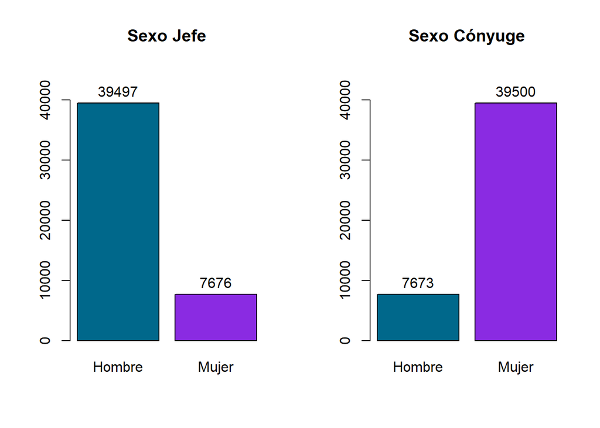

```r
library(knitr)
par(mfrow=c(1,2))
#Jefe
Sexo_jefe_table <- table(datos$Sexo_Jefe)
Sexo_jefe <- barplot(Sexo_jefe_table, col = c("deepskyblue4","blueviolet"), main = "Sexo Jefe",ylim = c(0,45000), names = c('Hombre','Mujer'))
text(Sexo_jefe,Sexo_jefe_table+2000,labels = Sexo_jefe_table)
#Conyuge
Sexo_conyuge_table <- table(datos$Sexo_Conyuge)
Sexo_conyuge <- barplot(table(datos$Sexo_Conyuge), col = c("deepskyblue4","blueviolet"), main = "Sexo Cónyuge",ylim = c(0,45000), names = c('Hombre','Mujer'))
text(Sexo_conyuge,Sexo_conyuge_table+2000,labels = Sexo_conyuge_table)
```

**ESTADO_CIVIL_Jefe/ESTADO_CIVIL_Conyuge**

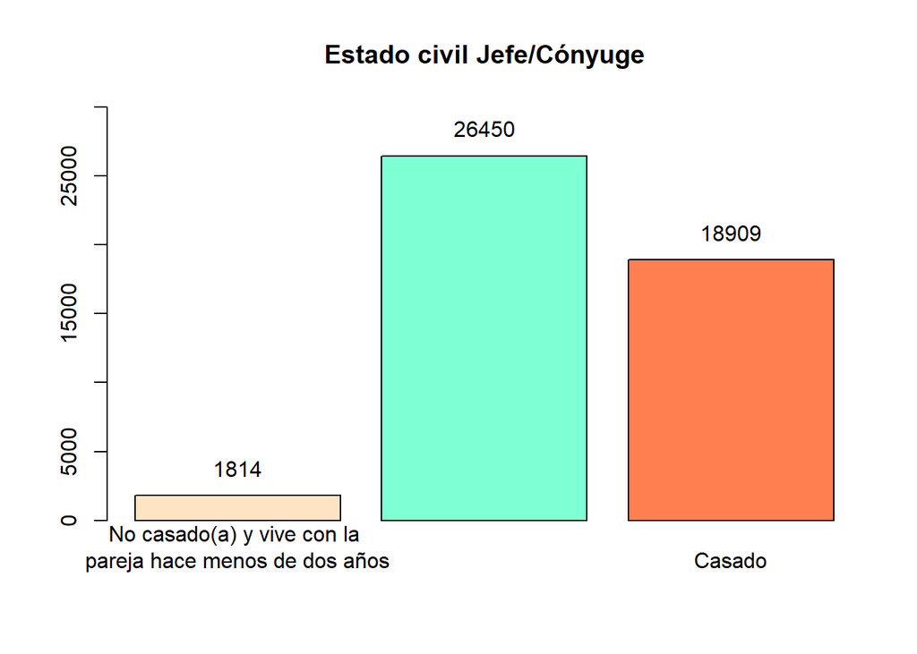

```r
#Jefe
Estado_civil_jefe_table <- table(datos$Estado_civil_Jefe)
Estado_civil_jefe <- barplot(Estado_civil_jefe_table, col = c("bisque","aquamarine","coral"), main = "Estado civil Jefe/Cónyuge",ylim = c(0,30000),names = c('No casado(a) y vive con la \npareja hace menos de dos años','No casado(a) y vive con \nla pareja hace más de dos años','Casado' ))
text(Estado_civil_jefe,Estado_civil_jefe_table+2000,labels = Estado_civil_jefe_table)
```

**PADRE_VIVE_Jefe/PADRE_VIVE_Cónyuge**

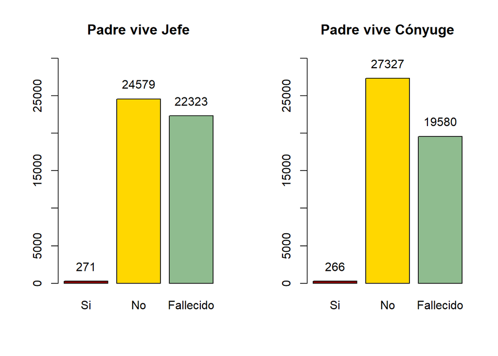

```r
par(mfrow=c(1,2))
#Jefe
Padre_vive_jefe_table <- table(datos$Padre_vive_Jefe)
Padre_vive_jefe <- barplot(Padre_vive_jefe_table, col = c("darkred","gold", "darkseagreen"), main = "Padre vive Jefe",ylim = c(0,30000), names = c('Si','No','Fallecido'))
text(Padre_vive_jefe,Padre_vive_jefe_table+2000,labels = Padre_vive_jefe_table)
#Conyuge
padre_vive_conyuge_table <- table(datos$Padre_vive_Conyuge)
padre_vive_conyuge <- barplot(table(datos$Padre_vive_Conyuge), col = c("darkred","gold", "darkseagreen"), main = "Padre vive Cónyuge",ylim = c(0,30000), names = c('Si','No','Fallecido'))
text(padre_vive_conyuge,padre_vive_conyuge_table+2000,labels = padre_vive_conyuge_table)
```

**MADRE_VIVE_Jefe / MADRE_VIVE_Cónyuge**

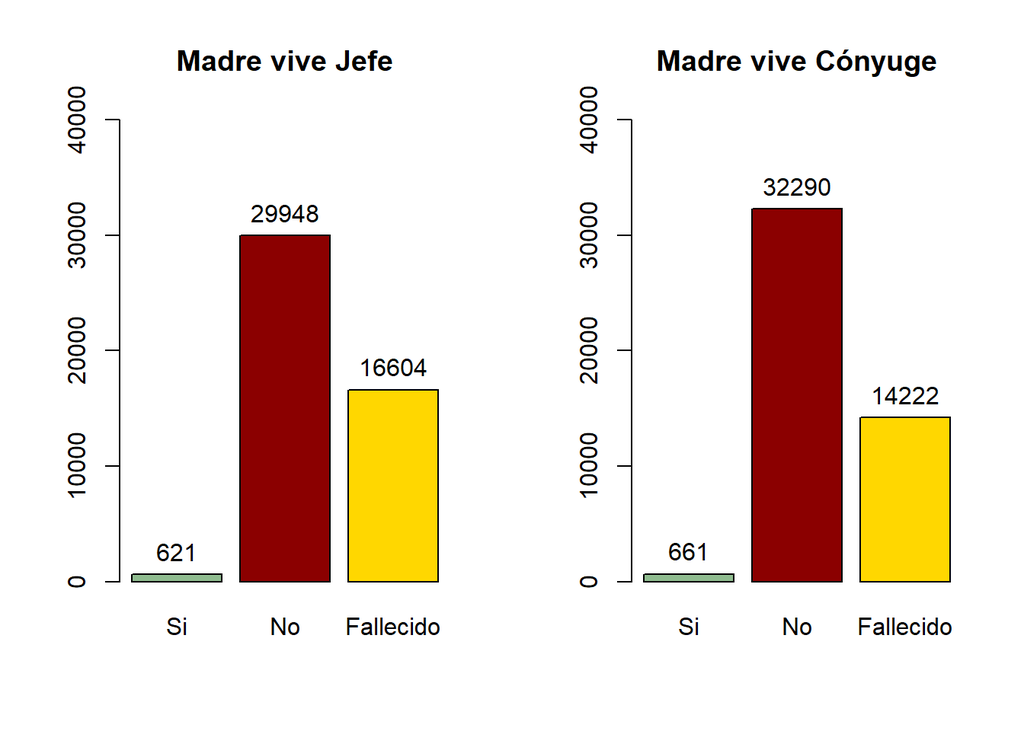

```r
par(mfrow=c(1,2))
#Jefe
Madre_vive_jefe_table <- table(datos$Madre_vive_Jefe)
Madre_vive_jefe <- barplot(Madre_vive_jefe_table, col = c("darkseagreen", "darkred","gold"), main = "Madre vive Jefe",ylim = c(0,40000), names = c('Si','No','Fallecido'))
text(Madre_vive_jefe,Madre_vive_jefe_table+2000,labels = Madre_vive_jefe_table)
#Conyuge
Madre_vive_conyuge_table <- table(datos$Madre_vive_Conyuge)
Madre_vive_conyuge <- barplot(table(datos$Madre_vive_Conyuge), col = c("darkseagreen", "darkred","gold"), main = "Madre vive Cónyuge",ylim = c(0,40000), names = c('Si','No','Fallecido'))
text(Madre_vive_conyuge,Madre_vive_conyuge_table+2000,labels = Madre_vive_conyuge_table)
```

**CULTURA_Jefe / CULTURA_Cónyuge**

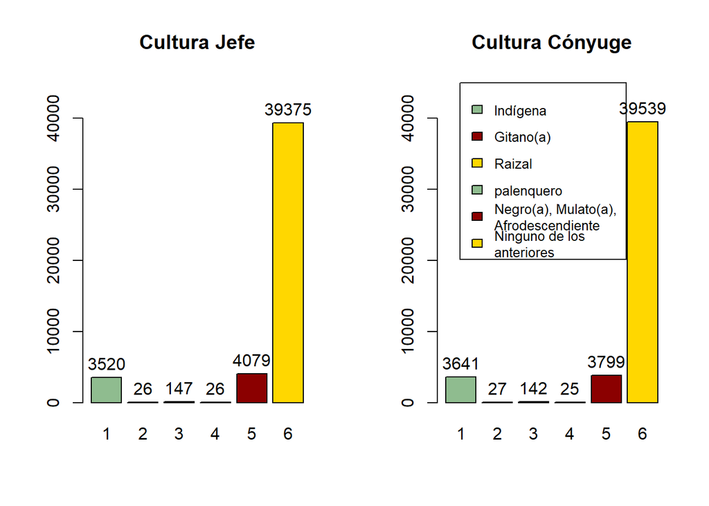

```r
par(mfrow=c(1,2))
#Jefe
Cultura_jefe_table <- table(datos$Cultura_Jefe)
Cultura_jefe <- barplot(Cultura_jefe_table, col = c("darkseagreen", "darkred","gold"), main = "Cultura Jefe",ylim = c(0,45000))
text(Cultura_jefe,Cultura_jefe_table+2000,labels = Cultura_jefe_table)
#Conyuge
Cultura_conyuge_table <- table(datos$Cultura_Conyuge)
Cultura_conyuge <- barplot(table(datos$Cultura_Conyuge), col = c("darkseagreen", "darkred","gold"), main = "Cultura Cónyuge",ylim = c(0,45000))
legend("topleft",legend= c('Indígena','Gitano(a)','Raizal','palenquero','Negro(a), Mulato(a), \nAfrodescendiente','Ninguno de los \nanteriores'),fill =c("darkseagreen", "darkred","gold"),xpd = TRUE,cex = 0.8,inset = c(0.1,0) )
text(Cultura_conyuge,Cultura_conyuge_table+2000,labels = Cultura_conyuge_table)
```

**CAMPESINO_Jefe / CAMPESINO_Cónyuge**

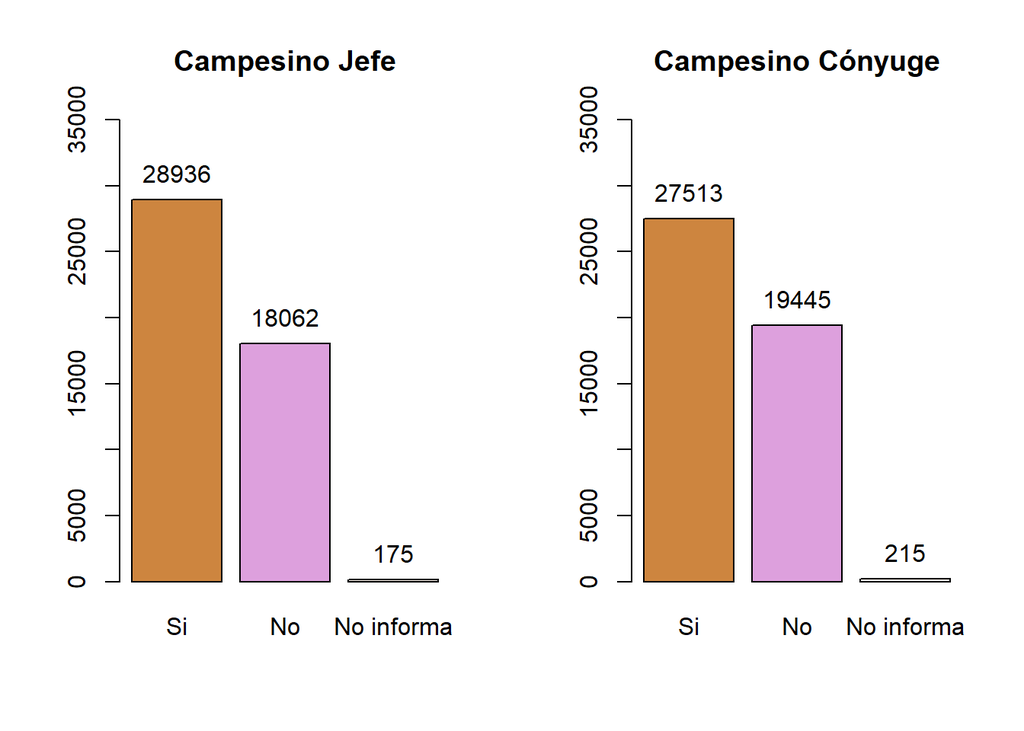

```r
par(mfrow=c(1,2))
#Jefe
Campesino_jefe_table <- table(datos$Campesino_Jefe)
Campesino_jefe <- barplot(Campesino_jefe_table, col = c("peru", "plum","seashell"), main = "Campesino Jefe",ylim = c(0,35000), names = c('Si','No','No informa'))
text(Campesino_jefe,Campesino_jefe_table+2000,labels = Campesino_jefe_table)
#Conyuge
Campesino_conyuge_table <- table(datos$Campesino_Conyuge)
Campesino_conyuge <- barplot(table(datos$Campesino_Conyuge), col = c("peru", "plum","seashell"), main = "Campesino Cónyuge",ylim = c(0,35000), names = c('Si','No','No informa'))
text(Campesino_conyuge,Campesino_conyuge_table+2000,labels = Campesino_conyuge_table)
```

**SATISFACCIÓN_VIDA_Jefe / SATISFACCIÓN_VIDA_Cónyuge**

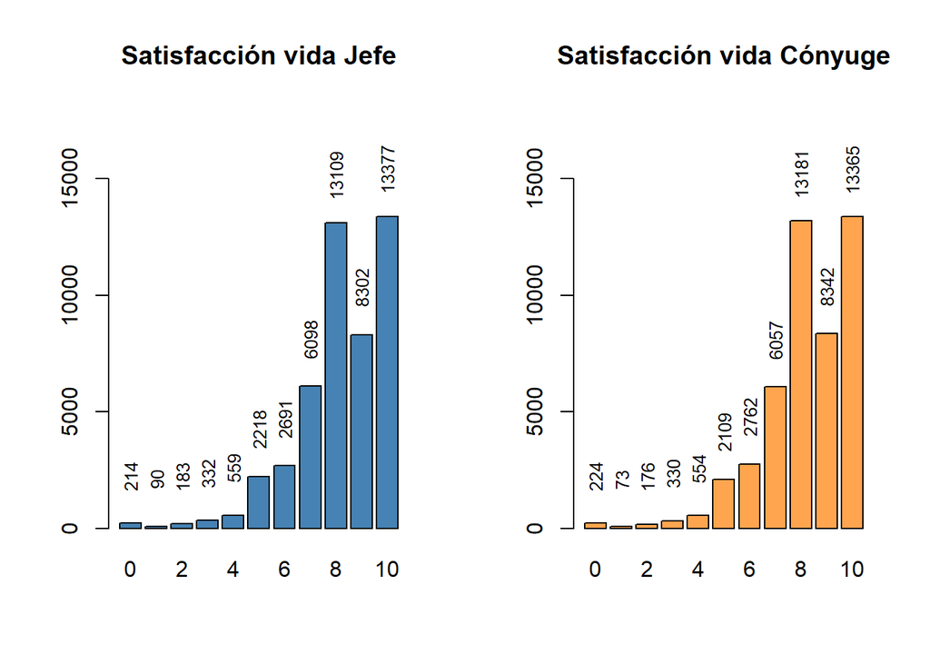

```r
par(mfrow=c(1,2))
#Jefe
Satisfaccion_vida_jefe_table <- table(datos$Satisfaccion_vida_Jefe)
Satisfaccion_vida_jefe <- barplot(Satisfaccion_vida_jefe_table, col = "steelblue", main = "Satisfacción vida Jefe",ylim = c(0,18000))
text(Satisfaccion_vida_jefe,Satisfaccion_vida_jefe_table+2000,labels = Satisfaccion_vida_jefe_table,srt=90,cex=0.8)
#Conyuge
Satisfaccion_vida_conyuge_table <- table(datos$Satisfaccion_vida_Conyuge)
Satisfaccion_vida_conyuge <- barplot(table(datos$Satisfaccion_vida_Conyuge), col = "tan1", main = "Satisfacción vida Cónyuge",ylim = c(0,18000))
text(Satisfaccion_vida_conyuge,Satisfaccion_vida_conyuge_table+2000,labels = Satisfaccion_vida_conyuge_table,srt=90,cex=0.8)
```

**SATISFACCIÓN_ECONÓMICA_Jefe / SATISFACCIÓN_ECONÓMICA_Cónyuge**

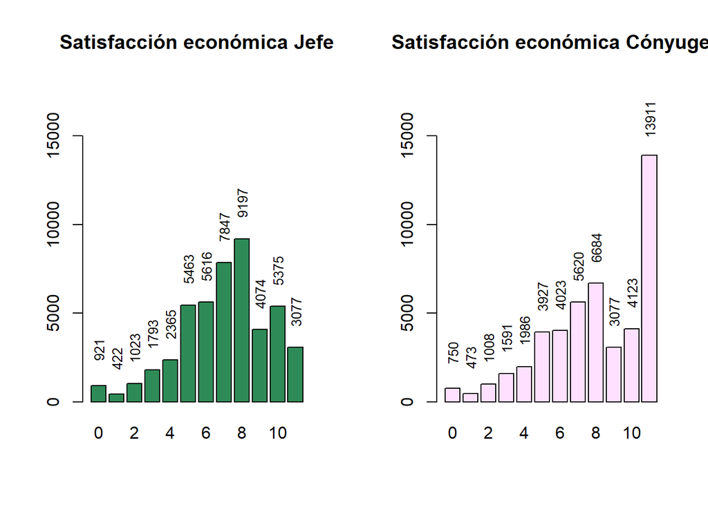

```r
par(mfrow=c(1,2))
#Jefe
Satisfaccion_economica_jefe_table <- table(datos$Satisfaccion_economica_Jefe)
Satisfaccion_economica_jefe <- barplot(Satisfaccion_economica_jefe_table, col = "seagreen4", main = "Satisfacción económica Jefe",ylim = c(0,18000))
text(Satisfaccion_economica_jefe,Satisfaccion_economica_jefe_table+2000,labels = Satisfaccion_economica_jefe_table,srt=90,cex=0.8)
#Conyuge
Satisfaccion_economica_conyuge_table <- table(datos$Satisfaccion_economica_Conyuge)
Satisfaccion_economica_conyuge <- barplot(Satisfaccion_economica_conyuge_table, col = "thistle1", main = "Satisfacción económica Cónyuge",ylim = c(0,18000))
text(Satisfaccion_economica_conyuge,Satisfaccion_economica_conyuge_table+2000,labels = Satisfaccion_economica_conyuge_table,srt=90,cex=0.8)
```

**SATISFACCIÓN_SALUD_Jefe / SATISFACCIÓN_SALUD_Cónyuge**

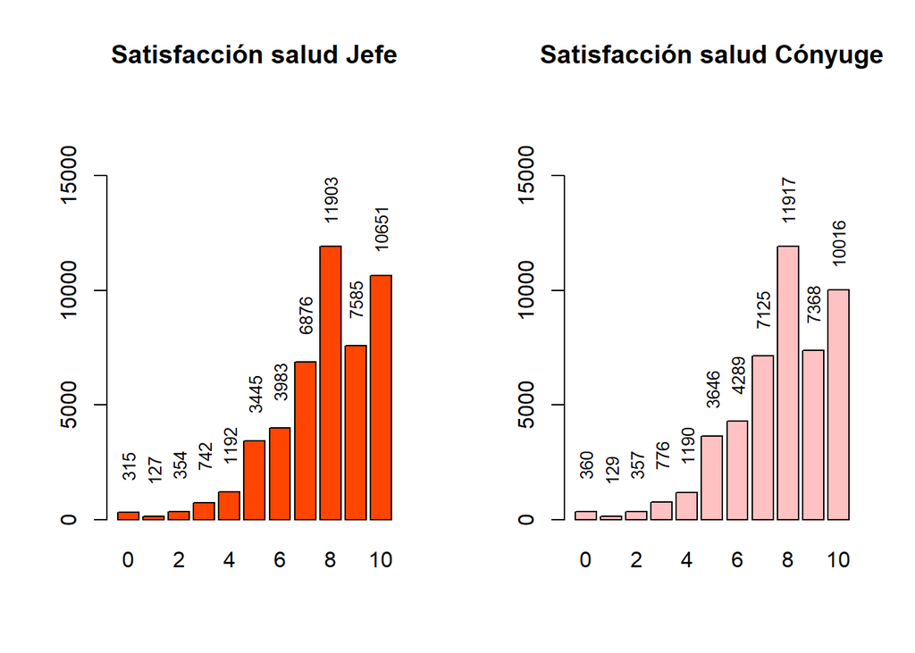

```r
par(mfrow=c(1,2))
#Jefe
Satisfaccion_salud_jefe_table <- table(datos$Satisfaccion_salud_Jefe)
Satisfaccion_salud_jefe <- barplot(Satisfaccion_salud_jefe_table, col = "orangered", main = "Satisfacción salud Jefe",ylim = c(0,18000))
text(Satisfaccion_salud_jefe,Satisfaccion_salud_jefe_table+2000,labels = Satisfaccion_salud_jefe_table,srt=90,cex=0.8)
#Conyuge
Satisfaccion_salud_conyuge_table <- table(datos$Satisfaccion_salud_Conyuge)
Satisfaccion_salud_conyuge <- barplot(Satisfaccion_salud_conyuge_table, col = "rosybrown1", main = "Satisfacción salud Cónyuge",ylim = c(0,18000))
text(Satisfaccion_salud_conyuge,Satisfaccion_salud_conyuge_table+2000,labels = Satisfaccion_salud_conyuge_table,srt=90,cex=0.8)
```

**SATISFACCIÓN_TRABAJO_Jefe / SATISFACCIÓN_TRABAJO_Cónyuge**

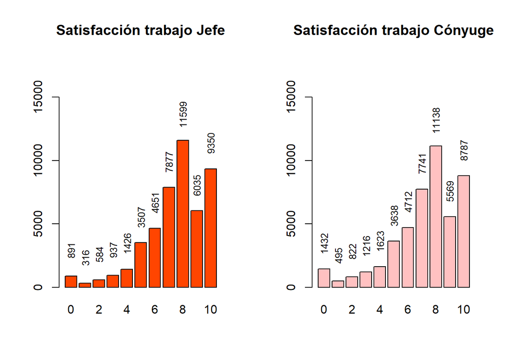

```r
par(mfrow=c(1,2))
#Jefe
Satisfaccion_trabajo_jefe_table <- table(datos$Satisfaccion_trabajo_Jefe)
Satisfaccion_trabajo_jefe <- barplot(Satisfaccion_trabajo_jefe_table, col = "orangered", main = "Satisfacción trabajo Jefe",ylim = c(0,18000))
text(Satisfaccion_trabajo_jefe,Satisfaccion_trabajo_jefe_table+2000,labels = Satisfaccion_trabajo_jefe_table,srt=90,cex=0.8)
#Conyuge
Satisfaccion_trabajo_conyuge_table <- table(datos$Satisfaccion_trabajo_Conyuge)
Satisfaccion_trabajo_conyuge <- barplot(Satisfaccion_trabajo_conyuge_table, col = "rosybrown1", main = "Satisfacción trabajo Cónyuge",ylim = c(0,18000))
text(Satisfaccion_trabajo_conyuge,Satisfaccion_trabajo_conyuge_table+2000,labels = Satisfaccion_trabajo_conyuge_table,srt=90,cex=0.8)
```

**FELICIDAD_Jefe / FELICIDAD_Cónyuge**

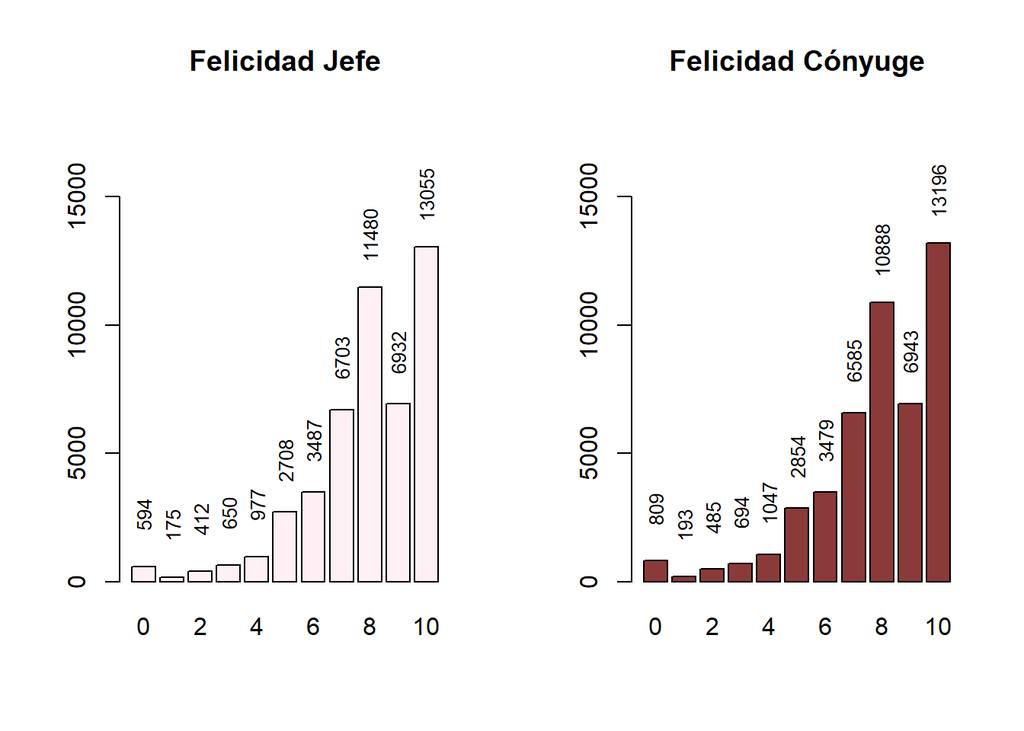

```r
par(mfrow=c(1,2))
#Jefe
Felicidad_jefe_table <- table(datos$Felicidad_Jefe)
Felicidad_jefe <- barplot(Felicidad_jefe_table, col = "lavenderblush", main = "Felicidad Jefe",ylim = c(0,18000))
text(Felicidad_jefe,Felicidad_jefe_table+2000,labels = Felicidad_jefe_table,srt=90,cex=0.8)
#Conyuge
Felicidad_conyuge_table <- table(datos$Felicidad_Conyuge)
Felicidad_conyuge <- barplot(Felicidad_conyuge_table, col = "indianred4", main = "Felicidad Cónyuge",ylim = c(0,18000))
text(Felicidad_conyuge,Felicidad_conyuge_table+2000,labels = Felicidad_conyuge_table,srt=90,cex=0.8)
```

**TRISTEZA_Jefe / TRISTEZA_Cónyuge**

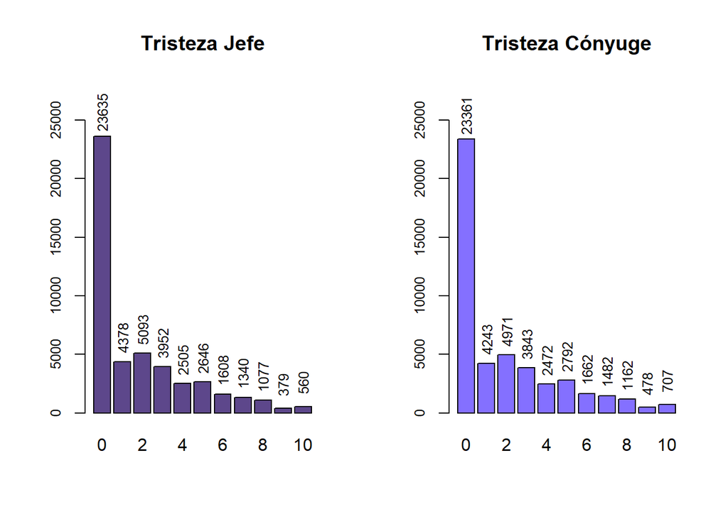

```r
par(mfrow=c(1,2))
#Jefe
Tristeza_jefe_table <- table(datos$Tristeza_Jefe)
Tristeza_jefe <- barplot(Tristeza_jefe_table, col = "mediumpurple4", main = "Tristeza Jefe",ylim = c(0,28000),cex.axis = 0.8)
text(Tristeza_jefe,Tristeza_jefe_table+2000,labels = Tristeza_jefe_table,srt=90,cex=0.8)
#Conyuge
Tristeza_conyuge_table <- table(datos$Tristeza_Conyuge)
Tristeza_conyuge <- barplot(Tristeza_conyuge_table, col = "lightslateblue", main = "Tristeza Cónyuge",ylim = c(0,28000),cex.axis = 0.8)
text(Tristeza_conyuge,Tristeza_conyuge_table+2000,labels = Tristeza_conyuge_table,srt=90,cex=0.8)
```

**ESCALÓN_VIDA_Jefe / ESCALÓN_VIDA_Cónyuge**

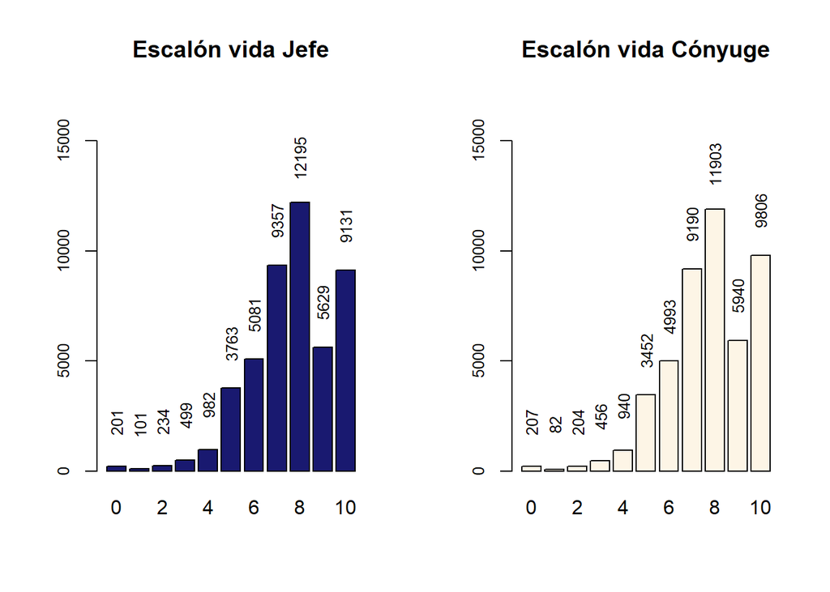

```r
par(mfrow=c(1,2))
#Jefe
Escalon_vida_jefe_table <- table(datos$Escalon_vida_Jefe)
Escalon_vida_jefe <- barplot(Escalon_vida_jefe_table, col = "midnightblue", main = "Escalón vida Jefe",ylim = c(0,17000),cex.axis = 0.8)
text(Escalon_vida_jefe,Escalon_vida_jefe_table+2000,labels = Escalon_vida_jefe_table,srt=90,cex=0.8)
#Conyuge
Escalon_vida_conyuge_table <- table(datos$Escalon_vida_Conyuge)
Escalon_vida_conyuge <- barplot(Escalon_vida_conyuge_table, col = "oldlace", main = "Escalón vida Cónyuge",ylim = c(0,17000),cex.axis = 0.8)
text(Escalon_vida_conyuge,Escalon_vida_conyuge_table+2000,labels = Escalon_vida_conyuge_table,srt=90,cex=0.8)
```

**REGIÓN**

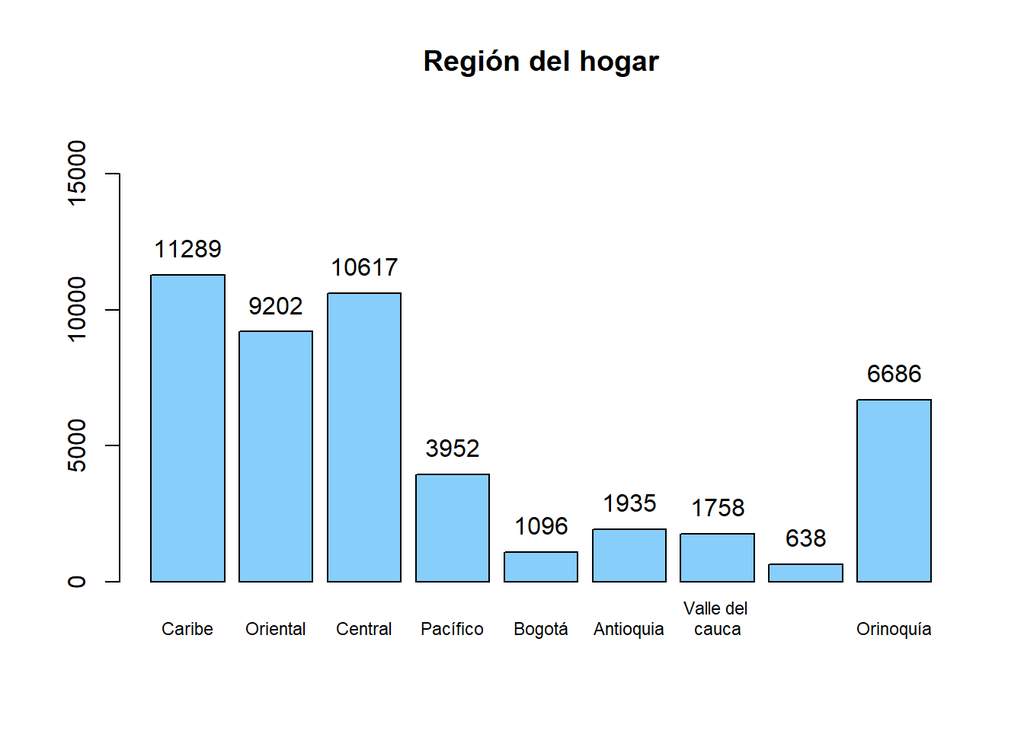

```r
Region_table <- table(datos$REGION)
Region <- barplot(Region_table, col = "lightskyblue", main = "Región del hogar",ylim = c(0,17000),names = c('Caribe','Oriental','Central','Pacífico','Bogotá','Antioquia','Valle del \ncauca','San andrés','Orinoquía'),cex.names = 0.71)
text(Region,Region_table+1000,labels = Region_table)
```

**UBICACIÓN**

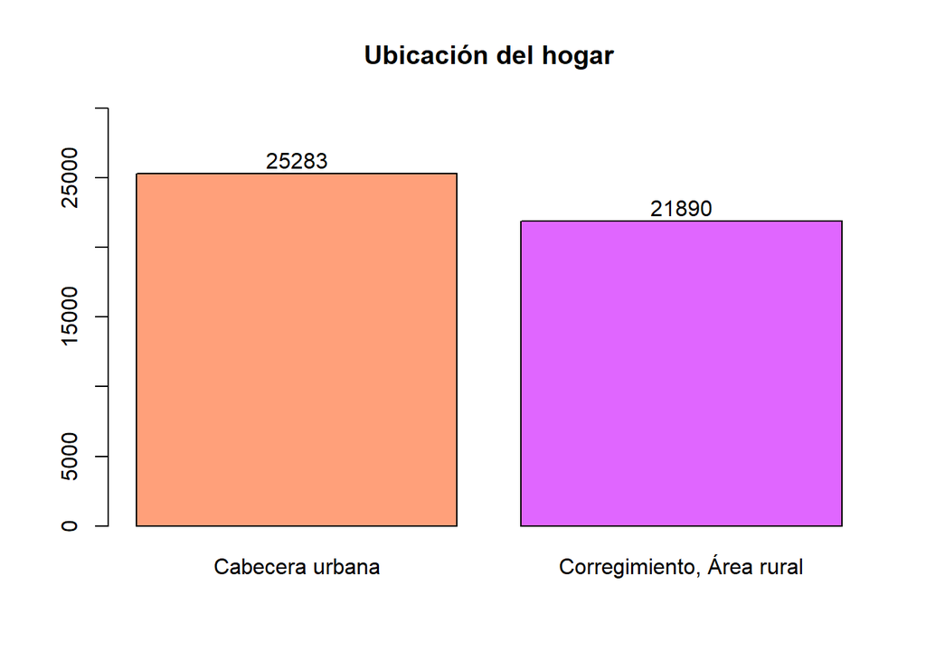

```r
Ubicacion_table <- table(datos$Ubicacion)
Ubicacion <- barplot(Ubicacion_table, col =c("lightsalmon","mediumorchid1"), main = "Ubicación del hogar",ylim = c(0,30000),names = c('Cabecera urbana','Corregimiento, Área rural'),cex.names = 1)
text(Ubicacion,Ubicacion_table+1000,labels = Ubicacion_table)
```

**Tipo_Vivienda**

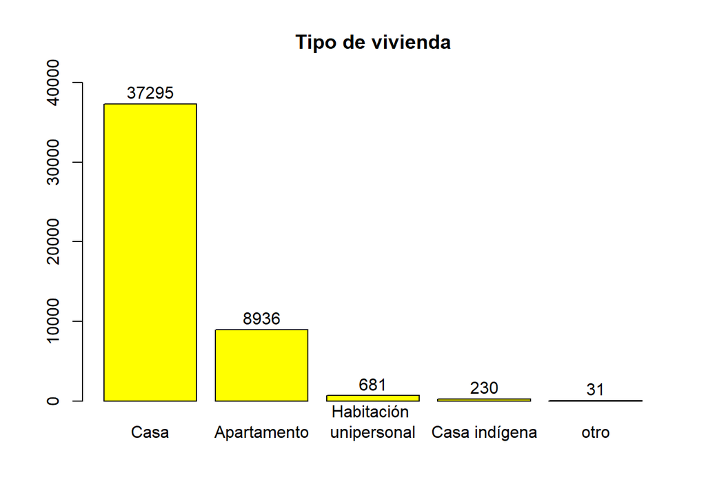

```r
Tipo_vivienda_table <- table(datos$Tipo_vivienda)
Tipo_vivienda <- barplot(Tipo_vivienda_table, col = 'yellow', main = "Tipo de vivienda",ylim = c(0,40000),names = c('Casa','Apartamento','Habitación \nunipersonal','Casa indígena','otro'),cex.names = 1)
text(Tipo_vivienda,Tipo_vivienda_table+1500,labels = Tipo_vivienda_table)
```

**Material_Exterior**

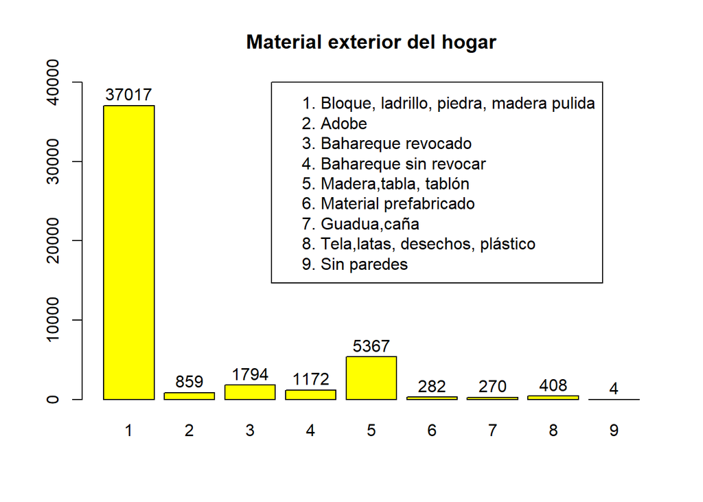

```r
Material_exterior_table <- table(datos$Material_exterior)
Material_exterior <- barplot(Material_exterior_table, col = 'yellow', main = "Material exterior del hogar",ylim = c(0,40000),cex.names = 1)
text(Material_exterior,Material_exterior_table+1500,labels = Material_exterior_table)
legend("topright",legend= c('1. Bloque, ladrillo, piedra, madera pulida','2. Adobe','3. Bahareque revocado','4. Bahareque sin revocar','5. Madera,tabla, tablón','6. Material prefabricado','7. Guadua,caña','8. Tela,latas, desechos, plástico','9. Sin paredes'),xpd = TRUE,cex = 1,inset = c(0.1,0) )
```

**Material_Piso**

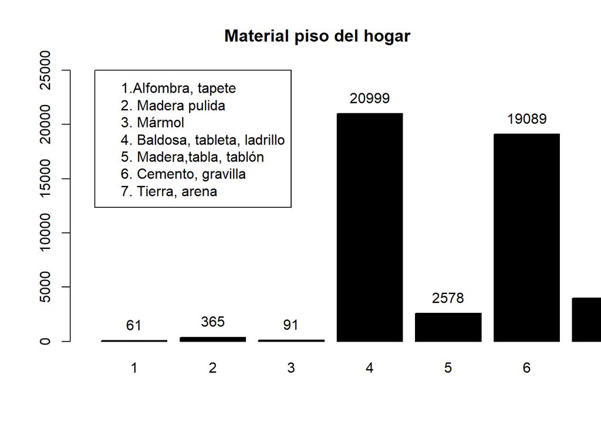

```r
Material_piso_table <- table(datos$Material_piso)
Material_piso <- barplot(Material_piso_table, col = 'black', main = "Material piso del hogar",ylim = c(0,25000),cex.names = 1, xlim = c(0,7))
text(Material_piso,Material_piso_table+1500,labels = Material_piso_table)
legend("topleft",legend= c('1.Alfombra, tapete','2. Madera pulida','3. Mármol','4. Baldosa, tableta, ladrillo','5. Madera,tabla, tablón','6. Cemento, gravilla','7. Tierra, arena'),xpd = TRUE,cex = 1,inset = c(0.05,0) )
```

**Material_Techo**

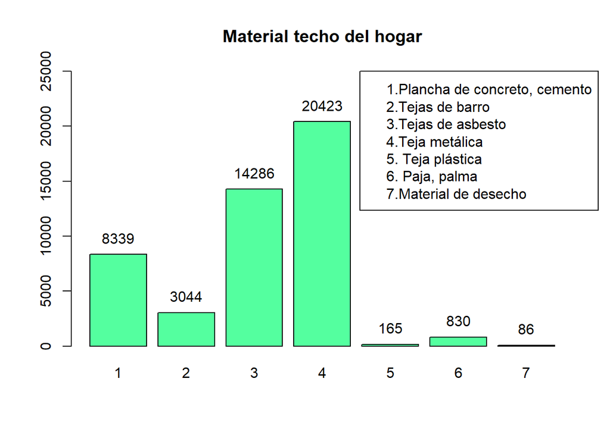

```r
Material_techo_table <- table(datos$Material_techo)
Material_techo <- barplot(Material_techo_table, col = 'seagreen1', main = "Material techo del hogar",ylim = c(0,25000),cex.names = 1)
text(Material_techo,Material_techo_table+1500,labels = Material_techo_table)
legend("topright",legend= c('1.Plancha de concreto, cemento','2.Tejas de barro','3.Tejas de asbesto','4.Teja metálica','5. Teja plástica','6. Paja, palma','7.Material de desecho'),xpd = TRUE,cex = 1,inset = c(-0.05,0) )
```

**Estrato**

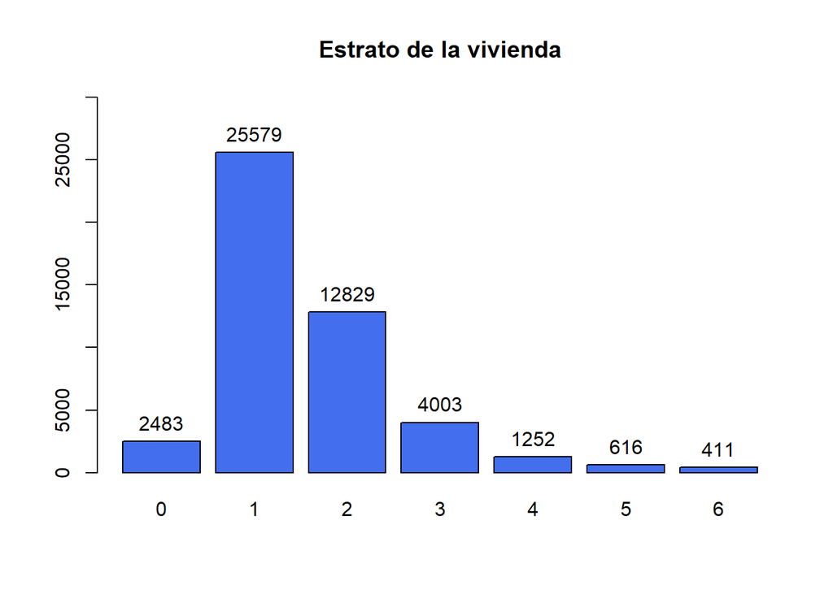

```r
Estrato_table <- table(datos$Estrato)
Estrato <- barplot(Estrato_table, col = 'royalblue2', main = "Estrato de la vivienda",ylim = c(0,30000),cex.names = 1)
text(Estrato,Estrato_table+1500,labels = Estrato_table)
```

**TIENE_EPS_Jefe / TIENE_EPS_Cónyuge**

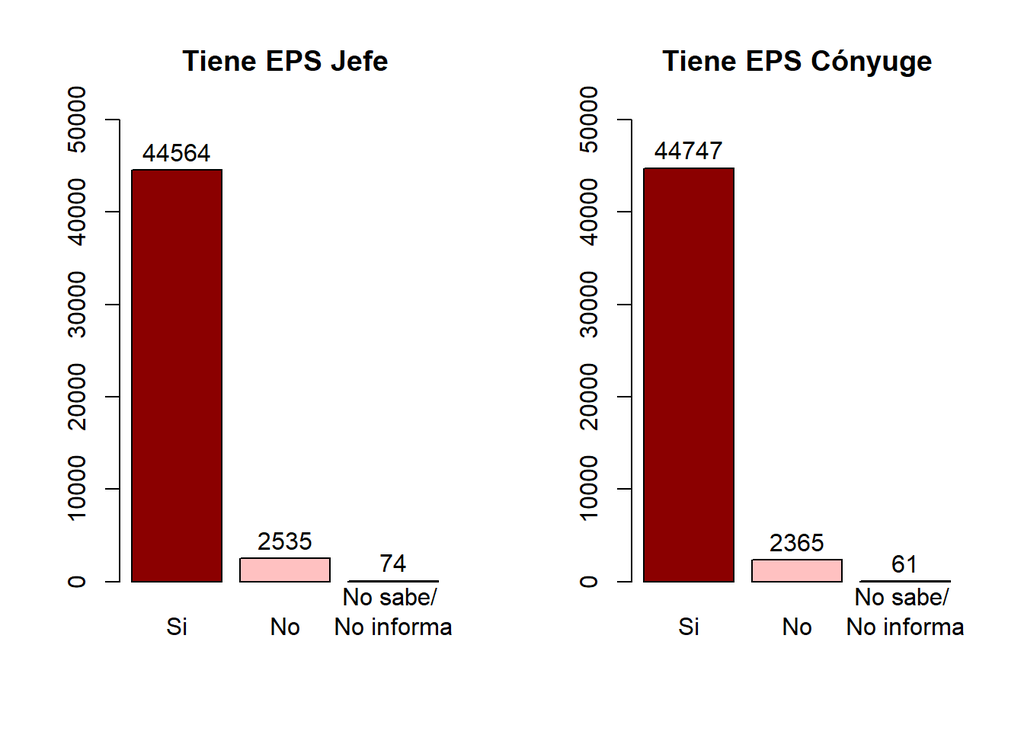

```r
par(mfrow=c(1,2))
#Jefe
Tiene_eps_jefe_table <- table(datos$Tiene_EPS_Jefe)
Tiene_eps_jefe <- barplot(Tiene_eps_jefe_table, col = c("red4", "rosybrown1", "sandybrown"), main = "Tiene EPS Jefe",ylim = c(0,50000), names = c('Si','No','No sabe/ \nNo informa'))
text(Tiene_eps_jefe,Tiene_eps_jefe_table+2000,labels = Tiene_eps_jefe_table)
#Conyuge
Tiene_eps_conyuge_table <- table(datos$Tiene_EPS_Conyuge)
Tiene_eps_conyuge <- barplot(Tiene_eps_conyuge_table, col = c("red4", "rosybrown1", "sandybrown"), main = "Tiene EPS Cónyuge",ylim = c(0,50000), names = c('Si','No','No sabe/ \nNo informa'))
text(Tiene_eps_conyuge,Tiene_eps_conyuge_table+2000,labels = Tiene_eps_conyuge_table)
```

**PERCEPCIÓN_Jefe / PERCEPCIÓN_Cónyuge**

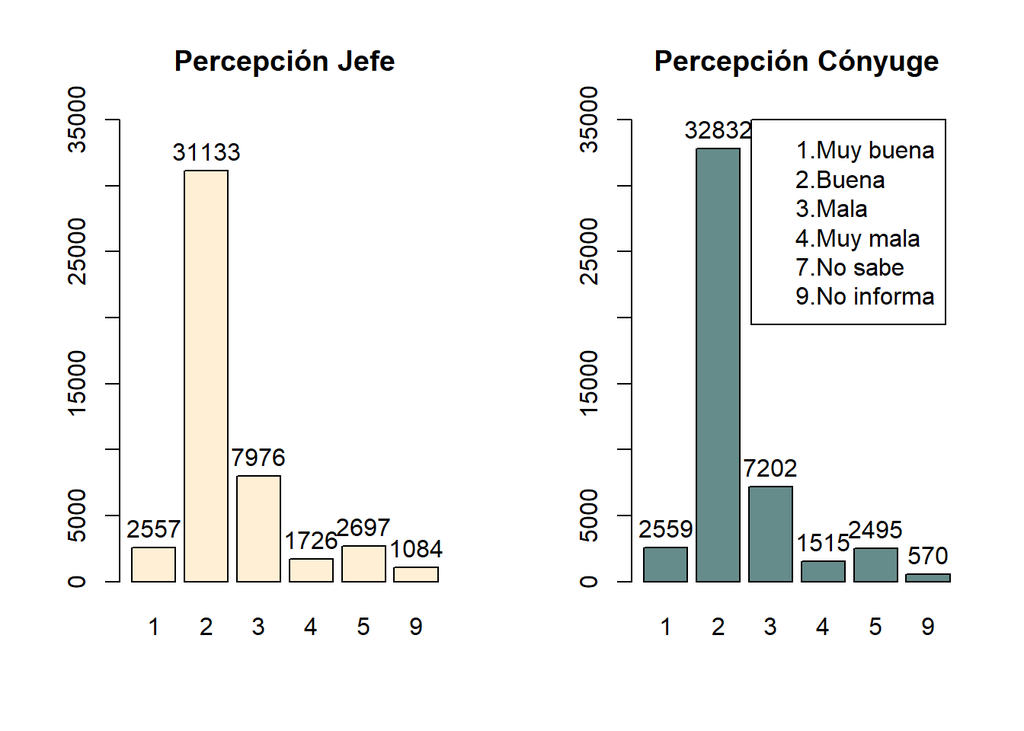

```r
par(mfrow=c(1,2))
#Jefe
Percepcion_jefe_table <- table(datos$Percepcion_Jefe)
Percepcion_jefe <- barplot(Percepcion_jefe_table, col = "papayawhip", main = "Percepción Jefe",ylim = c(0,35000))
text(Percepcion_jefe,Percepcion_jefe_table+1500,labels = Percepcion_jefe_table)
#Conyuge
Percepcion_conyuge_table <- table(datos$Percepcion_Conyuge)
Percepcion_conyuge <- barplot(Percepcion_conyuge_table, col = "paleturquoise4", main = "Percepción Cónyuge",ylim = c(0,35000))
text(Percepcion_conyuge,Percepcion_conyuge_table+1500,labels = Percepcion_conyuge_table)
legend("topright",legend= c('1.Muy buena','2.Buena','3.Mala','4.Muy mala','7.No sabe','9.No informa'),xpd = TRUE,cex = 1,inset = c(0.05,0) )
```

**PREPAGADA_Jefe / PREPAGADA_Cónyuge**

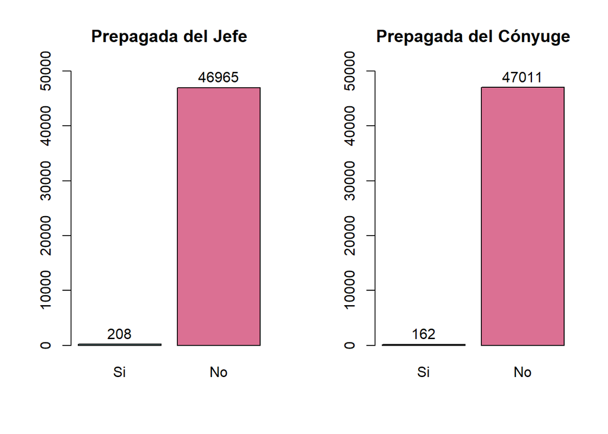

```r
par(mfrow=c(1,2))
#Jefe
Prepagada_jefe_table <- table(datos$Prepagada_Jefe)
Prepagada_jefe <- barplot(Prepagada_jefe_table, col = c("paleturquoise4","palevioletred"), main = "Prepagada del Jefe",ylim = c(0,50000), names = c('Si','No'))
text(Prepagada_jefe,Prepagada_jefe_table+2000,labels = Prepagada_jefe_table)
#Conyuge
Prepagada_conyuge_table <- table(datos$Prepagada_Conyuge)
Prepagada_conyuge <- barplot(Prepagada_conyuge_table, col = c("paleturquoise4","palevioletred"), main = "Prepagada del Cónyuge",ylim = c(0,50000), names = c('Si','No'))
text(Prepagada_conyuge,Prepagada_conyuge_table+2000,labels = Prepagada_conyuge_table)
```

**ESTADO_SALUD_Jefe / ESTADO_SALUD_Cónyuge**

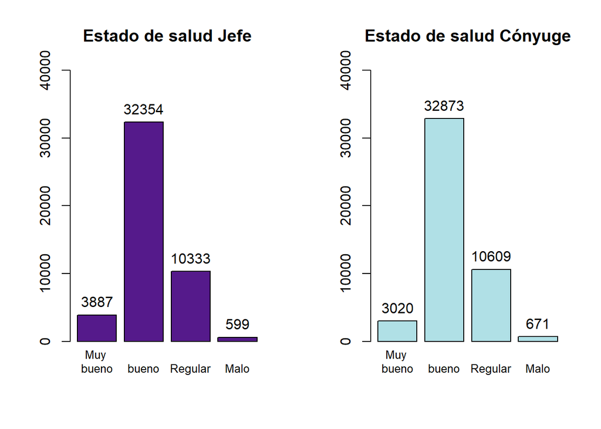

```r
par(mfrow=c(1,2))
#Jefe
Estado_salud_jefe_table <- table(datos$Estado_salud_Jefe)
Estado_salud_jefe <- barplot(Estado_salud_jefe_table, col = "purple4", main = "Estado de salud Jefe",ylim = c(0,40000), names = c('Muy \nbueno','bueno','Regular','Malo'),cex.names = 0.8)
text(Estado_salud_jefe,Estado_salud_jefe_table+2000,labels = Estado_salud_jefe_table)
#Conyuge
Estado_salud_conyuge_table <- table(datos$Estado_salud_Conyuge)
Estado_salud_conyuge <- barplot(Estado_salud_conyuge_table, col = "powderblue", main = "Estado de salud Cónyuge",ylim = c(0,40000), names = c('Muy \nbueno','bueno','Regular','Malo'), cex.names = 0.8)
text(Estado_salud_conyuge,Estado_salud_conyuge_table+2000,labels = Estado_salud_conyuge_table)
```

**ENFERMEDAD_GRAVE_Jefe / ENFERMEDAD_GRAVE_Cónyuge**

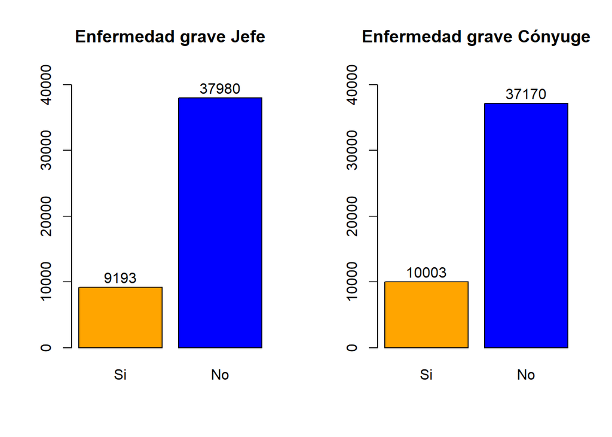

```r
par(mfrow=c(1,2))
#Jefe
Enfermedad_grave_jefe_table <- table(datos$Enfermedad_grave_Jefe)
Enfermedad_grave_jefe <- barplot(Enfermedad_grave_jefe_table, col = c("orange","blue"), main = "Enfermedad grave Jefe",ylim = c(0,42000), names = c('Si','No'))
text(Enfermedad_grave_jefe,Enfermedad_grave_jefe_table+1500,labels = Enfermedad_grave_jefe_table)
#Conyuge
Enfermedad_grave_conyuge_table <- table(datos$Enfermedad_grave_Conyuge)
Enfermedad_grave_conyuge <- barplot(Enfermedad_grave_conyuge_table, col = c("orange","blue"), main = "Enfermedad grave Cónyuge",ylim = c(0,42000), names = c('Si','No'))
text(Enfermedad_grave_conyuge,Enfermedad_grave_conyuge_table+1500,labels = Enfermedad_grave_conyuge_table)
```

**SABE_ESCRIBIR_LEER_Jefe / SABE_ESCRIBIR_LEER_Cónyuge**

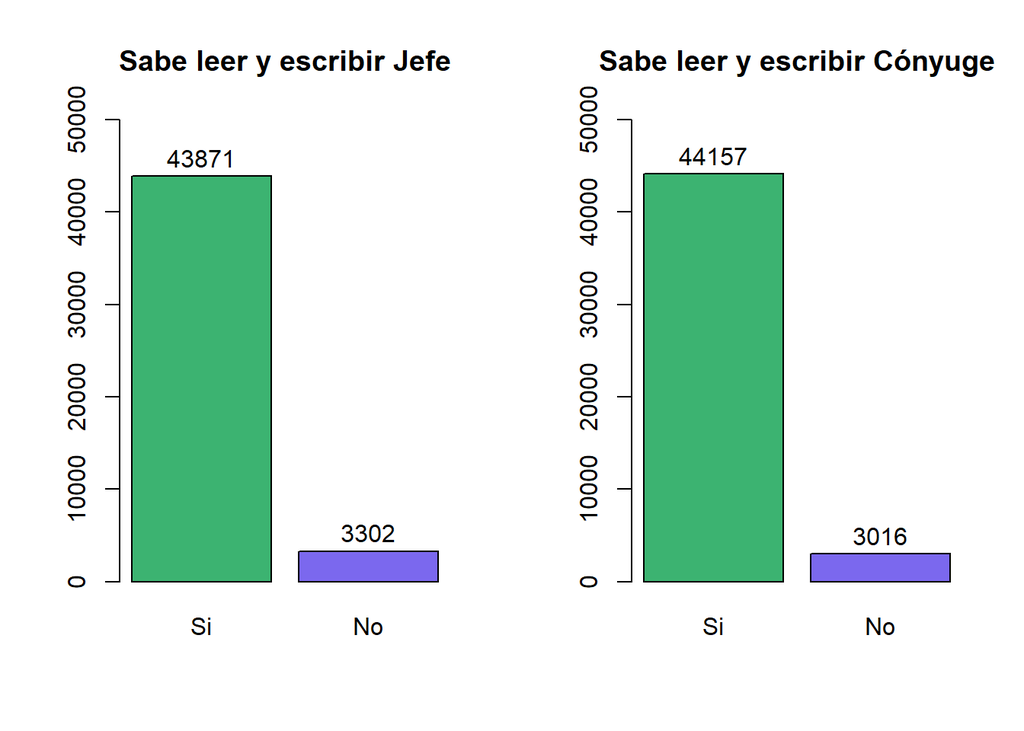

```r
par(mfrow=c(1,2))
#Jefe
Sabe_escribir_jefe_table <- table(datos$Sabe_escribir_leer_Jefe)
Sabe_escribir_jefe <- barplot(Sabe_escribir_jefe_table, col = c("mediumseagreen","mediumslateblue"), main = "Sabe leer y escribir Jefe",ylim = c(0,50000), names = c('Si','No'))
text(Sabe_escribir_jefe,Sabe_escribir_jefe_table+2000,labels = Sabe_escribir_jefe_table)
#Conyuge
Sabe_escribir_conyuge_table <- table(datos$Sabe_escribir_leer_Conyuge)
Sabe_escribir_conyuge <- barplot(Sabe_escribir_conyuge_table, col = c("mediumseagreen","mediumslateblue"), main = "Sabe leer y escribir Cónyuge",ylim = c(0,50000), names = c('Si','No'))
text(Sabe_escribir_conyuge,Sabe_escribir_conyuge_table+2000,labels = Sabe_escribir_conyuge_table)
```

**ESTUDIA_Jefe / ESTUDIA_Cónyuge**

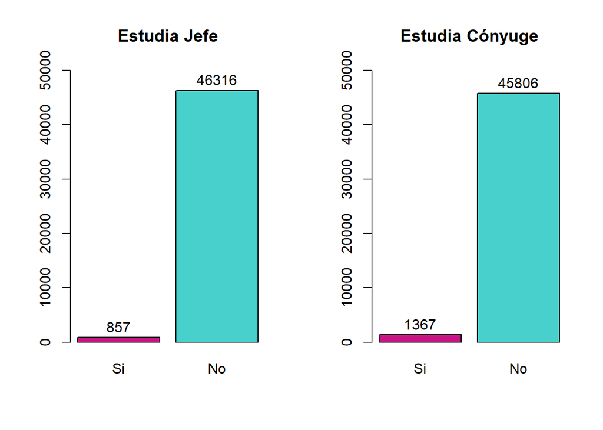

```r
par(mfrow=c(1,2))
#Jefe
Estudia_jefe_table <- table(datos$Estudia._Jefe)
Estudia_jefe <- barplot(Estudia_jefe_table, col = c("mediumvioletred","mediumturquoise"), main = "Estudia Jefe",ylim = c(0,50000), names = c('Si','No'))
text(Estudia_jefe,Estudia_jefe_table+2000,labels = Estudia_jefe_table)
#Conyuge
Estudia_conyuge_table <- table(datos$Estudia._Conyuge)
Estudia_conyuge <- barplot(Estudia_conyuge_table, col = c("mediumvioletred","mediumturquoise"), main = "Estudia Cónyuge",ylim = c(0,50000), names = c('Si','No'))
text(Estudia_conyuge,Estudia_conyuge_table+2000,labels = Estudia_conyuge_table)
```

**NIVEL_EDUCATIVO_Jefe / NIVEL_EDUCATIVO_Cónyuge**

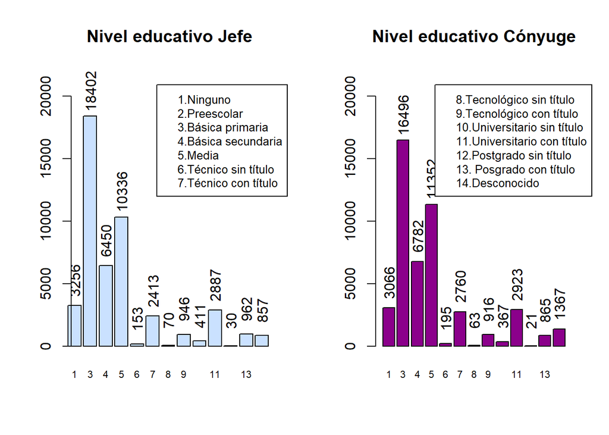

```r
par(mfrow=c(1,2))
#Jefe
Nivel_educativo_jefe_table <- table(datos$Nivel_educativo_Jefe)
Nivel_educativo_jefe <- barplot(Nivel_educativo_jefe_table, col = "lightsteelblue1", main = "Nivel educativo Jefe",ylim = c(0,22000),cex.names = 0.7, xlim = c(1,15))
text(Nivel_educativo_jefe,Nivel_educativo_jefe_table+2000,labels = Nivel_educativo_jefe_table,srt=90)
legend("topright",legend= c('1.Ninguno','2.Preescolar','3.Básica primaria','4.Básica secundaria','5.Media','6.Técnico sin título','7.Técnico con título'),xpd = TRUE,cex = 0.8,inset = c(-0.1,0.05) )
#Conyuge
Nivel_educativo_conyuge_table <- table(datos$Nivel_educativo_Conyuge)
Nivel_educativo_conyuge <- barplot(Nivel_educativo_conyuge_table, col = "magenta4", main = "Nivel educativo Cónyuge",ylim = c(0,22000),cex.names = 0.7)
text(Nivel_educativo_conyuge,Nivel_educativo_conyuge_table+2000,labels = Nivel_educativo_conyuge_table,srt=90)
legend("topright",legend= c('8.Tecnológico sin título','9.Tecnológico con título','10.Universitario sin título','11.Universitario con título','12.Postgrado sin título','13. Posgrado con título','14.Desconocido'),xpd = TRUE,cex = 0.8,inset = c(-0.1,0.05) )
```

**PÚBLICO_PRIVADO_Jefe / PÚBLICO_PRIVADO_Cónyuge**

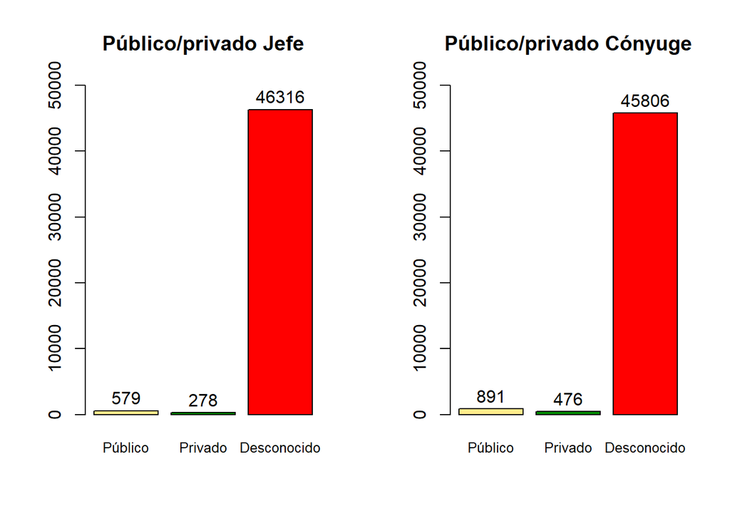

```r
par(mfrow=c(1,2))
#Jefe
Publico_privado_jefe_table <- table(datos$Publico_privado_Jefe)
Publico_privado_jefe <- barplot(Publico_privado_jefe_table, col = c("lightgoldenrod1","green4","red"), main = "Público/privado Jefe",ylim = c(0,50000), names = c('Público','Privado','Desconocido'),cex.names = 0.8)
text(Publico_privado_jefe,Publico_privado_jefe_table+2000,labels = Publico_privado_jefe_table)
#Conyuge
Publico_privado_conyuge_table <- table(datos$Publico_privado_Conyuge)
Publico_privado_conyuge <- barplot(Publico_privado_conyuge_table, col = c("lightgoldenrod1","green4","red"), main = "Público/privado Cónyuge",ylim = c(0,50000), names = c('Público','Privado','Desconocido'),cex.names = 0.8)
text(Publico_privado_conyuge,Publico_privado_conyuge_table+2000,labels = Publico_privado_conyuge_table)
```

**ACTIVIDAD_Jefe / ACTIVIDAD_Cónyuge**

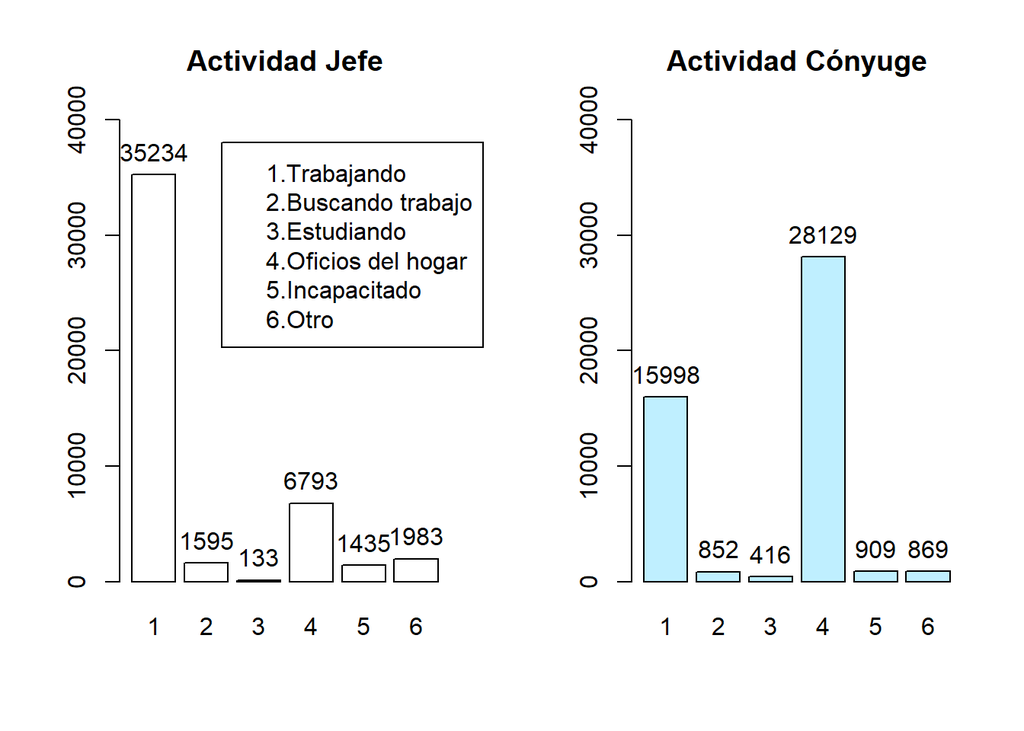

```r
par(mfrow=c(1,2))
#Jefe
Actividad_jefe_table <- table(datos$Actividad_Jefe)
Actividad_jefe <- barplot(Actividad_jefe_table, col = "white", main = "Actividad Jefe",ylim = c(0,40000))
text(Actividad_jefe,Actividad_jefe_table+2000,labels = Actividad_jefe_table)
legend("topright",legend= c('1.Trabajando','2.Buscando trabajo','3.Estudiando','4.Oficios del hogar','5.Incapacitado','6.Otro'),xpd = TRUE,cex = 1,inset = c(-0.1,0.05) )
#Conyuge
Actividad_conyuge_table <- table(datos$Actividad_Conyuge)
Actividad_conyuge <- barplot(Actividad_conyuge_table, col = "lightblue1", main = "Actividad Cónyuge",ylim = c(0,40000))
text(Actividad_conyuge,Actividad_conyuge_table+2000,labels = Actividad_conyuge_table)
```